# ▒ 군집분석 ▒

### **0. 환경설정**

```r
# install.packages("kohonen")
# install.packages("dbscan")
library(kohonen)
library(dbscan)
library(readxl)
library(tidyverse)
options(repr.plot.width = 5, repr.plot.height = 4) #그림 크기 옵션
```

### **1. 데이터 불러오기**

**[데이터 다운로드]**

- C드라이브에 [R_project] 폴더 생성
- [R_project] 폴더에 [DAT] 폴더 생성
- 데이터 스토어에서 샘플데이터(3.아파트_주소기반_주택지역특성시세정보_DB.xlsx)를 “C:/R_project/DAT/”에 다운로드 (https://www.datastore.or.kr/file/detail?id=2c0a9616-4d78-403c-9d77-3db2effb2a74&page=1&viewCount=10&sort=1&order=1&source=1&keyword=%EC%95%84%ED%8C%8C%ED%8A%B8)
- 서울/수도권 및 5대광역시 아파트에 대한 주소테이블 외 4개의 테이블(정보집단)로 구성되며 각각 주택특성정보, 지역특성정보, 가격/신뢰등급/예상회수율정보 테이블로 이루어져 있고, 각 테이블간은 고유키값(NUM)으로 연계되어 있음

**[데이터 호출]** 용산구 데이터

```r
path                  <- "C:/R_project/DAT/3.아파트_주소기반_주택지역특성시세정보_DB.xlsx"
sheet.names           <- excel_sheets(path)

df1                   <- read_excel(path, sheet.names[1])
df2                   <- read_excel(path, sheet.names[2])
df3                   <- read_excel(path, sheet.names[3])
df4                   <- read_excel(path, sheet.names[4])
data                  <- Reduce(function(x, y) merge(x, y, all=FALSE), list(df1, df2, df3, df4))

data$LAND_ACCESS      <- as.numeric(as.character(data$LAND_ACCESS))
data                  <- data[complete.cases(data), ]

gu_rows               <- data$SGG == "용산구"  # 용산구에 해당하는 데이터 행
gu_data               <- data[gu_rows, ]

EMD_data              <- gu_data[!duplicated(gu_data$EMD), c(8, 52, 53)]
head(EMD_data)
```

```
##           EMD SUPPLY EXCESS_DEMAND
## 128 원효로1가  12114          1510
## 133    신창동  12114          1510
## 134    산천동  12114          1510
## 141    효창동  12114          1510
## 143    도원동   8475          2441
## 152    용문동   8411          3026
```

- EMD: 읍, 면, 동
- SUPPLY: 주택수
- EXCESS_DEMAND: 초과수요

### **2. 계층적 군집분석**

**[유사도 거리 계산]** 유클리드거리

```r
attach(EMD_data)
x                     <- EMD_data[, 2:3]
D1                    <- dist(x)
D1
```

```
##           128       133       134       141       143       152       154
## 133    0.0000
## 134    0.0000    0.0000
## 141    0.0000    0.0000    0.0000
## 143 3756.2058 3756.2058 3756.2058 3756.2058
## 152 4001.3079 4001.3079 4001.3079 4001.3079  588.4904
## 154 1666.6283 1666.6283 1666.6283 1666.6283 4233.2720 4248.4097
## 161 4207.5228 4207.5228 4207.5228 4207.5228  987.0370  398.5486 4306.2069
## 165  315.9019  315.9019  315.9019  315.9019 3996.5275 4266.5824 1874.8717
## 167  315.9019  315.9019  315.9019  315.9019 3996.5275 4266.5824 1874.8717
## 173  315.9019  315.9019  315.9019  315.9019 3996.5275 4266.5824 1874.8717
## 174  315.9019  315.9019  315.9019  315.9019 3996.5275 4266.5824 1874.8717
## 180 3518.7960 3518.7960 3518.7960 3518.7960 1518.3231 2106.8128 4556.7165
## 223 3526.2531 3526.2531 3526.2531 3526.2531 1031.3200 1619.8099 4398.9159
## 227 3654.8194 3654.8194 3654.8194 3654.8194 2333.3077 2921.7974 4918.6223
## 238 1516.4317 1516.4317 1516.4317 1516.4317 4550.1236 4614.5676  504.1676
## 242 2363.3165 2363.3165 2363.3165 2363.3165 6102.6490 6301.9865 2554.7769
##           161       165       167       173       174       180       223
## 133
## 134
## 141
## 143
## 152
## 154
## 161
## 165 4485.5941
## 167 4485.5941    0.0000
## 173 4485.5941    0.0000    0.0000
## 174 4485.5941    0.0000    0.0000    0.0000
## 180 2505.3601 3659.5821 3659.5821 3659.5821 3659.5821
## 223 2018.3570 3703.8576 3703.8576 3703.8576 3703.8576  487.0031
## 227 3320.3447 3729.7133 3729.7133 3729.7133 3729.7133  814.9847 1301.9877
## 238 4701.3561 1650.7129 1650.7129 1650.7129 1650.7129 4727.8259 4617.6074
## 242 6465.4813 2177.2352 2177.2352 2177.2352 2177.2352 5833.3299 5878.5966
##           227       238
## 133
## 134
## 141
## 143
## 152
## 154
## 161
## 165
## 167
## 173
## 174
## 180
## 223
## 227
## 238 5014.0341
## 242 5848.5843 2050.6097
```

**[유사도 거리 계산]** 맨하탄거리

```r
D2                    <- dist(x, method = "manhattan")
D2
```

```
##      128  133  134  141  143  152  154  161  165  167  173  174  180  223
## 133    0
## 134    0    0
## 141    0    0    0
## 143 4570 4570 4570 4570
## 152 5219 5219 5219 5219  649
## 154 2120 2120 2120 2120 4828 4307
## 161 5660 5660 5660 5660 1090  441 4630
## 165  438  438  438  438 5008 5657 2208 6098
## 167  438  438  438  438 5008 5657 2208 6098    0
## 173  438  438  438  438 5008 5657 2208 6098    0    0
## 174  438  438  438  438 5008 5657 2208 6098    0    0    0
## 180 4049 4049 4049 4049 1677 2326 6169 2767 3961 3961 3961 3961
## 223 3619 3619 3619 3619 1139 1788 5739 2229 3869 3869 3869 3869  538
## 227 4769 4769 4769 4769 2577 3226 6889 3667 4681 4681 4681 4681  900 1438
## 238 2121 2121 2121 2121 4829 4902  713 5343 2209 2209 2209 2209 6170 5740
## 242 2583 2583 2583 2583 7153 7802 3613 8243 2209 2209 2209 2209 6170 6014
##      227  238
## 133
## 134
## 141
## 143
## 152
## 154
## 161
## 165
## 167
## 173
## 174
## 180
## 223
## 227
## 238 6890
## 242 6890 2900
```

**[계층적 군집 분석]** 최단 연결법

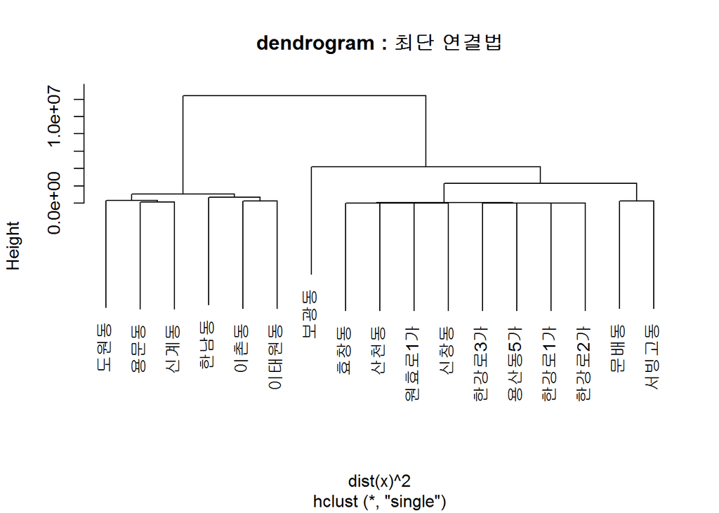

```r
hc1                   <- hclust(dist(x)^2, method = "single")
plot(hc1, labels = EMD, hang = 1, main = "dendrogram : 최단 연결법")
```

**[계층적 군집 분석]** 최장 연결법

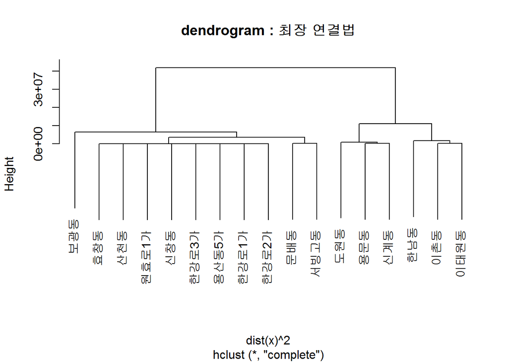

```r
hc2                   <- hclust(dist(x)^2, method = "complete")
plot(hc2, labels = EMD, hang=1, main = "dendrogram : 최장 연결법")
```

**[군집 설정 및 시각화]** 군집 수 설정 후 그룹 별 산점도로 결과 확인 : 최단 연결법

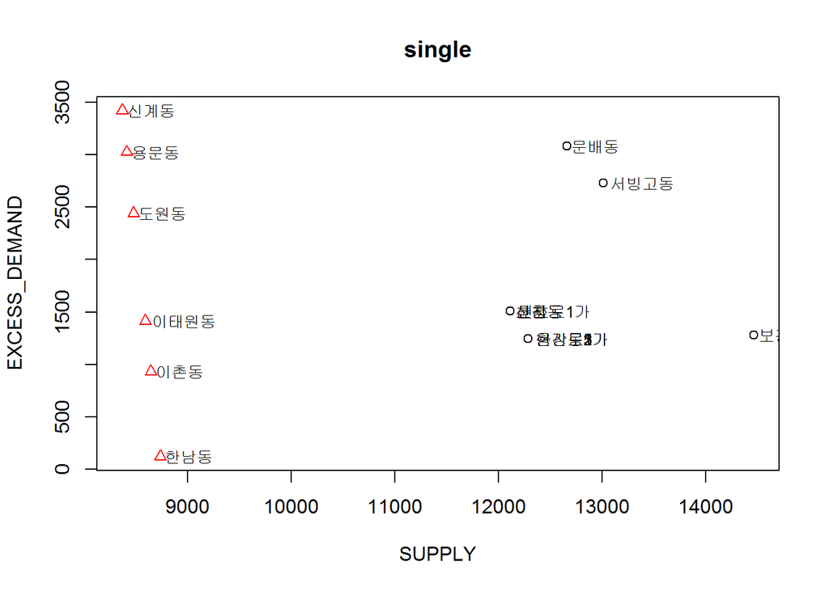

```r
c1.num                <- 2
hc1.result            <- cutree(hc1, k = c1.num) #최단 연결법 결과
plot(x, pch = hc1.result, col = hc1.result, main = "single")
text(x, labels = EMD, adj = -0.1, cex = 0.8)
```

**[군집 설정 및 시각화]** 군집 수 설정 후 그룹 별 산점도로 결과 확인 : 최장 연결법

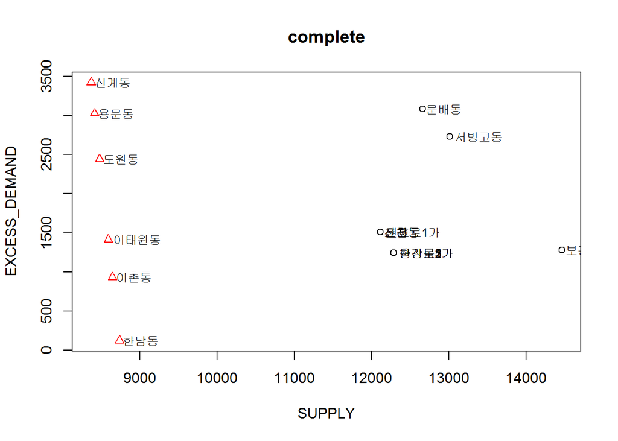

```r
hc2.result            <- cutree(hc2, k = c1.num)
plot(x, pch =  hc2.result, col = hc2.result, main = "complete")
text(x, labels = EMD, adj = -0.1, cex = 0.8)
```

### **3. 비계층적 군집분석**

**k-means clustering**

**[군집 설정]** 군집 수 = 3

```r
data_k                <- kmeans(x ,centers = 3)
attributes(data_k)
```

```
## $names
## [1] "cluster"      "centers"      "totss"        "withinss"
## [5] "tot.withinss" "betweenss"    "size"         "iter"
## [9] "ifault"
##
## $class
## [1] "kmeans"
```

```r
data_k$cluster
```

```
## 128 133 134 141 143 152 154 161 165 167 173 174 180 223 227 238 242
##   2   2   2   2   3   3   2   3   1   1   1   1   3   3   3   2   1
```

**[군집화]** grouping

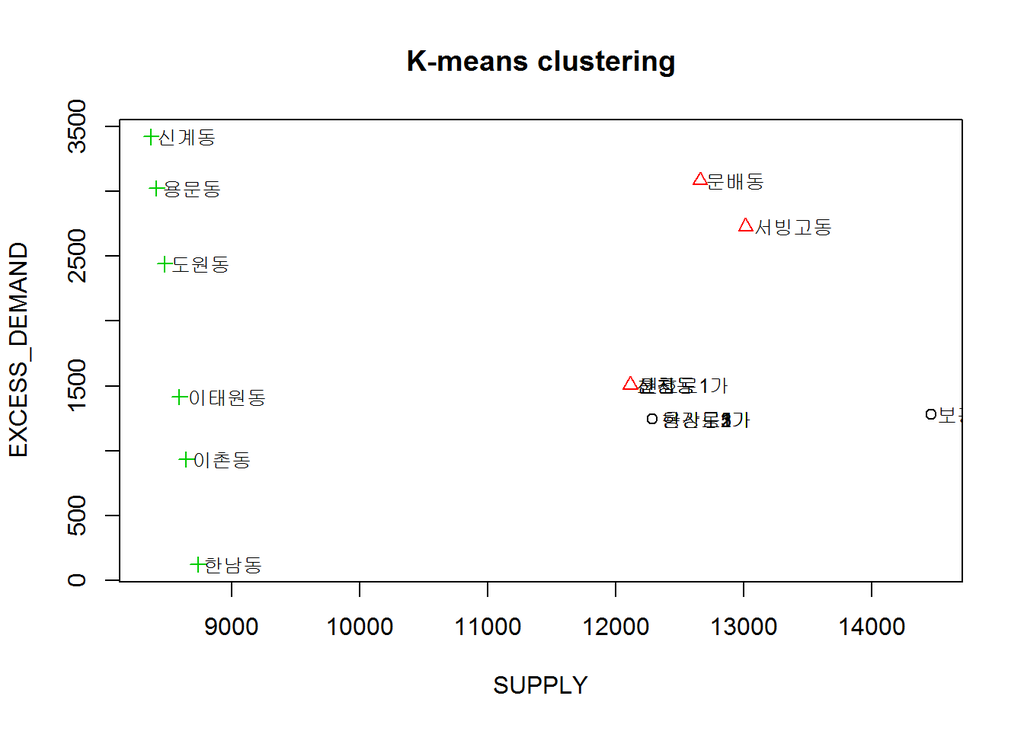

```r
clus                  <- cbind(EMD_data, x, data_k$cluster)
clus1                 <- clus[(clus[,4] == 1), ]
clus2                 <- clus[(clus[,4] == 2), ]
clus3                 <- clus[(clus[,4] == 3), ]
kc                    <- table(data_k$cluster)
plot(x, pch = data_k$cluster, col = data_k$cluster, main = "K-means clustering")
text(x, labels = EMD, adj = -0.1, cex = 0.8)
```

**SOM(Self-Organization-Map)**

**[데이터 호출]**

```r
som_data              <- data[!duplicated(EMD), c(48:53)]
head(som_data, 5)
```

```
##   POPULATION HOUSEHOLD      PPH SINGLE_HOUSEHOLD SUPPLY EXCESS_DEMAND
## 1       9584      4577 2.093948             2207   7872          2454
## 2       9584      4577 2.093948             2207   7872          2454
## 3       9584      4577 2.093948             2207   7872          2454
## 4       9584      4577 2.093948             2207   7872          2454
## 5       9584      4577 2.093948             2207   8330          3753
```

- POPULATION: 인구수
- HOUSEHOLD: 가구수
- PPH: 세대당 인구수
- SINGLE_HOUSEHOLD: 1인 가구수
- SUPPLY: 주택수
- EXCESS_DEMAND: 초과수요

**[데이터 변환]** 변수들간의 표준화(단위 환산)

```r
apart.sc              <- scale(som_data)
```

**[분석]** grid 설정 후 군집분석  
som에 활용할 grid는 somgrid함수 활용 + xdim, ydim : dimensions of the grid + topo : 각 노드들이 연결되는 방식

```r
set.seed(7)
apart.som             <- som(apart.sc, grid = somgrid(13, 13, topo = "hexagonal"))
```

**[결과]** SOM 결과 확인

```r
summary(apart.som)
```

```
## SOM of size 13x13 with a hexagonal topology and a bubble neighbourhood function.
## The number of data layers is 1.
## Distance measure(s) used: sumofsquares.
## Training data included: 495 objects.
## Mean distance to the closest unit in the map: 0.133.
```

**[시각화]**

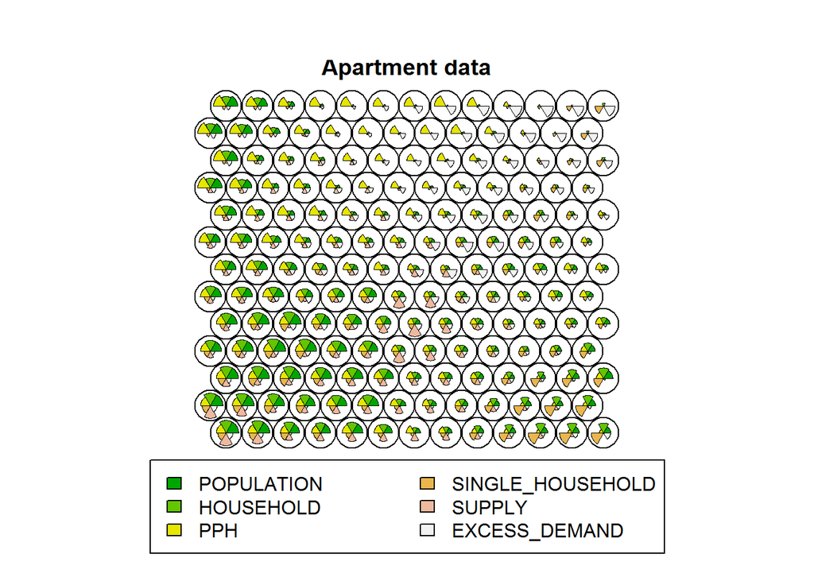

```r
plot(apart.som, main="Apartment data")
```

**[시각화]** SOM 분류결과 : count

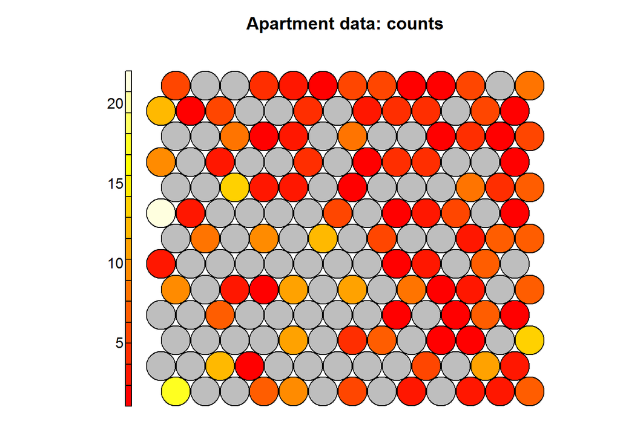

```r
plot(apart.som, type="counts", main="Apartment data: counts")
```

**[시각화]** SOM 분류결과 : quality

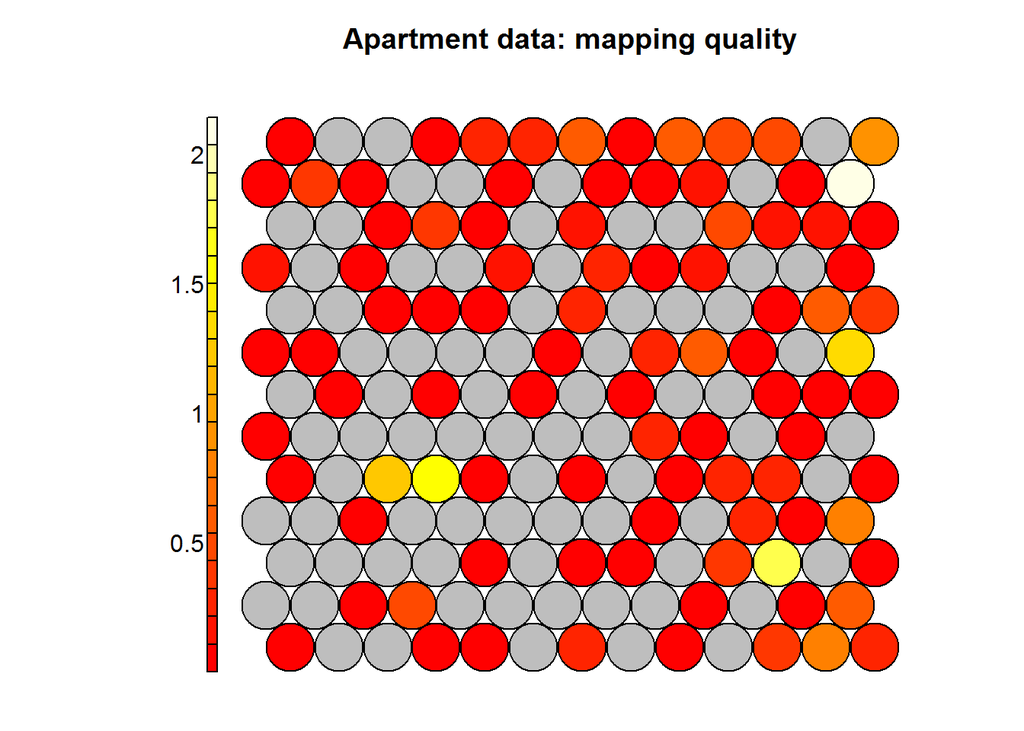

```r
plot(apart.som, type="quality", main="Apartment data: mapping quality")
```

**[시각화]** SOM 분류결과 : mapping

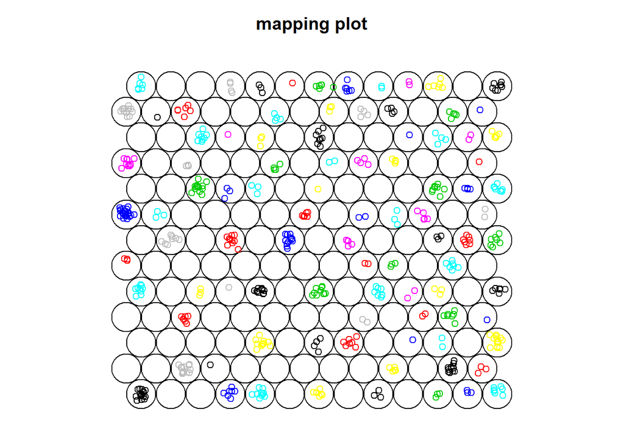

```r
plot(apart.som, type="mapping", col = apart.som$unit.classif, main="mapping plot")
```

**[시각화]** SOM code vector에 따른 분류결과 색으로 구분

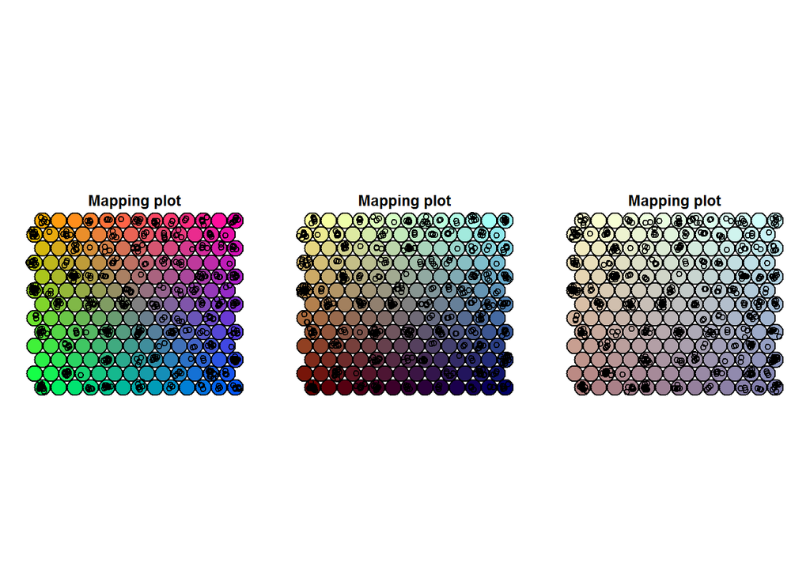

```r
par(mfrow=c(1, 3))
colour1               <- tricolor(apart.som$grid)
plot(apart.som, "mapping", bg=rgb(colour1))
colour2               <- tricolor(apart.som$grid, phi=c(pi/6, 0, -pi/6))
plot(apart.som, "mapping", bg=rgb(colour2))
colour3               <- tricolor(apart.som$grid, phi=c(pi/6, 0, -pi/6), offset= .5)
plot(apart.som, "mapping", bg=rgb(colour3))
```